# Data Visualization Course Final Project, Fall 2021

### Views of Absentee Voting by Presidential Vote Choice in 2020 Election

#### How confident are you that votes cast by absentee or mail-in ballot across the United States were counted as voters intended in the elections this November?

November 12-17, 2020  
Source: Pew Research Center’s American Trends Panel

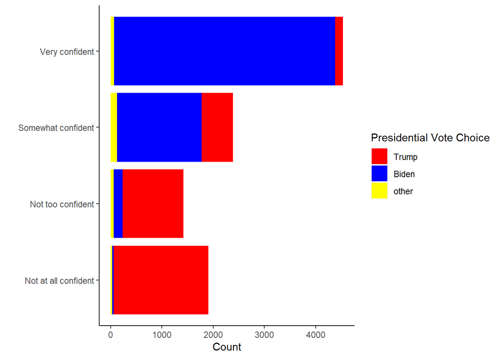

### Views of Trump and the Quality of 2020 Election Administration

#### How well do you think the 2020 election was administered?

November 12-17, 2020  
Source: Pew Research Center’s American Trends Panel

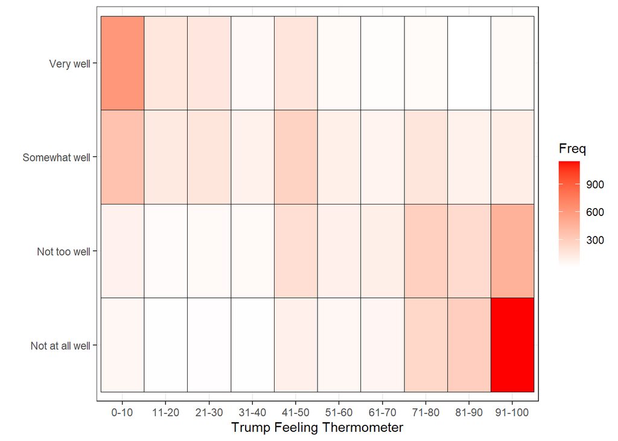

### Views of Trump and His Legal Challenges to 2020 Election

#### The Trump Campaign _____ continue these legal challenges.

November 12-17, 2020  
Source: Pew Research Center’s American Trends Panel

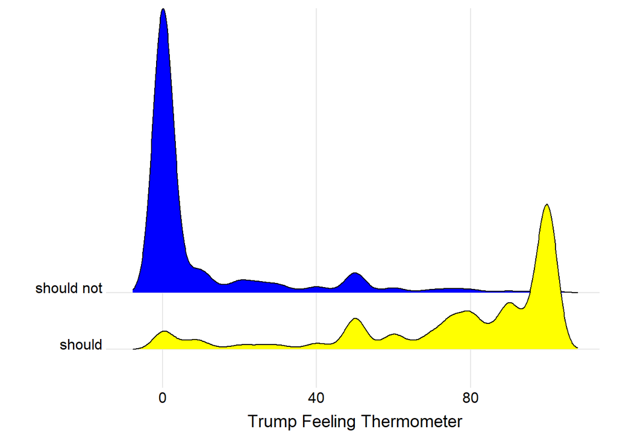

### Views of Prosecuting January 6 Rioters

#### How important, if at all, do you think it is for federal law enforcement agencies to find and prosecute those who broke into the U.S. Capitol on January 6?

March 1-7, 2021  
Source: Pew Research Center’s American Trends Panel

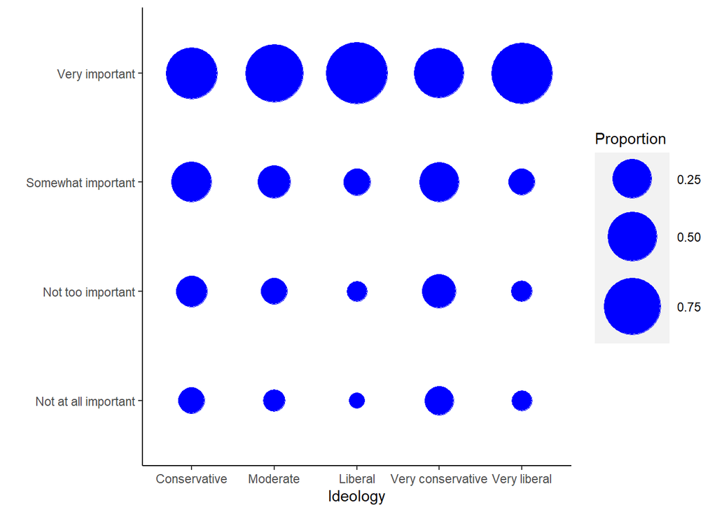

### Views of Trump and Vote Count Accuracy in 2020 Election

#### How confident are you that your vote was accurately counted?

November 12-17, 2020  
Source: Pew Research Center’s American Trends Panel

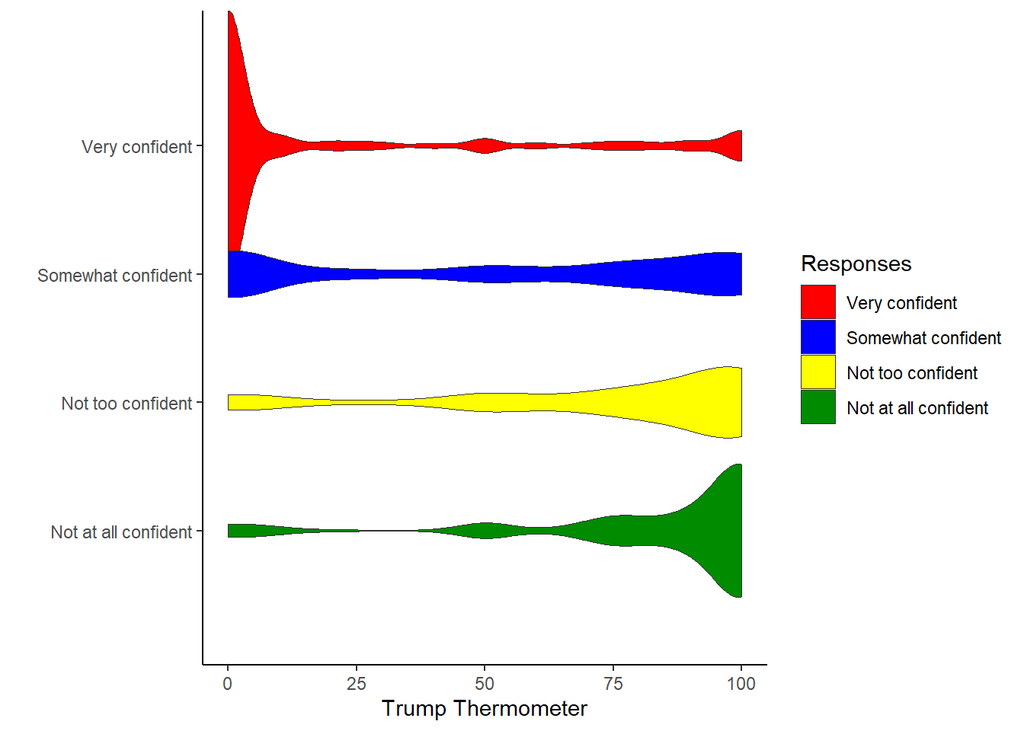

### Trust in Election Officials by Party

#### How much do you trust the officials who oversee elections where you live?

August 18 - November 3, 2020  
Source: American National Election Studies

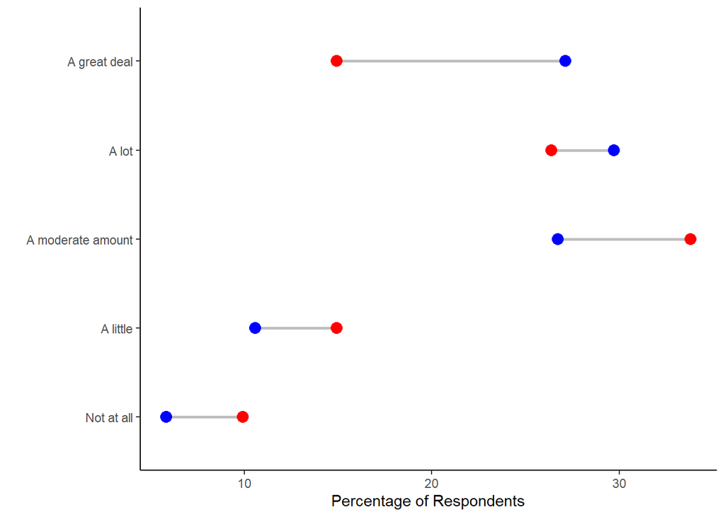

### Views of Trump’s Message after 2020 Election by Respondents’ Primary Source of News

#### From what you’ve seen or heard, do you generally think Donald Trump has been delivering the right message or the wrong message to the country following the presidential election?

November 18-29, 2020  
Source: Pew Research Center’s American Trends Panel

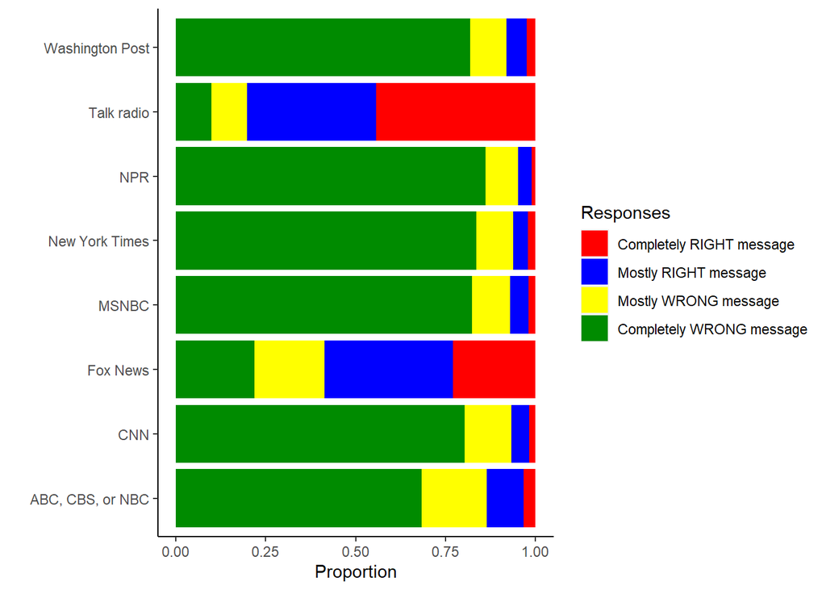

### Views of Government Responsiveness by Respondents’ Education Level, Gender, and Age

#### How much do you feel that having elections makes the government pay attention to what the people think?

August 18 - November 3, 2020  
Source: American National Election Studies

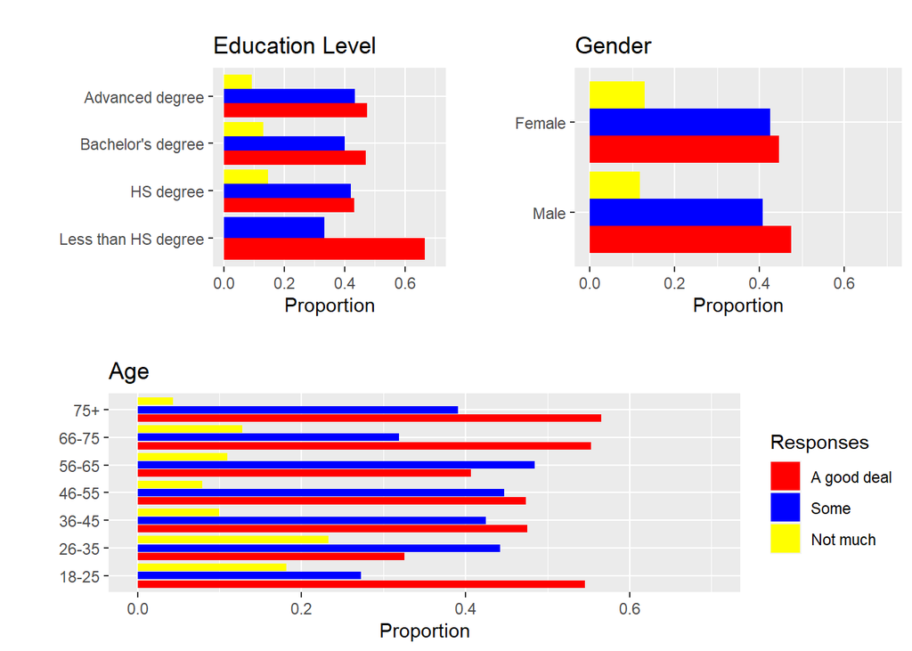

### Views of Vote Count Fairness by Respondents’ Ratings of Trump

#### How often are votes counted fairly in this country’s elections?

November 8, 2020 - January 4, 2021  
Source: American National Election Studies

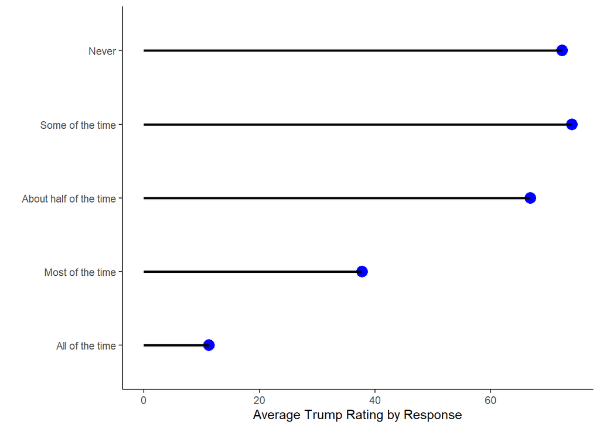